# Titanic Survival Prediction

Satsawat N.

December 24, 2016

## Quick Introduction

The popular Titanic dataset ia available and as part of practice competition in [Kaggle](https://www.kaggle.com/c/titanic). This provides very interesting and a first-step to world of machine learning and prediction for anyone who is interested in.

Let’s load the training datasets and have a quick look.

```
## [1] 891  12
```

```
## 'data.frame':    891 obs. of  12 variables:
##  $ passengerid: int  1 2 3 4 5 6 7 8 9 10 ...
##  $ survived   : int  0 1 1 1 0 0 0 0 1 1 ...
##  $ pclass     : int  3 1 3 1 3 3 1 3 3 2 ...
##  $ name       : chr  "Braund, Mr. Owen Harris" "Cumings, Mrs. John Bradley (Florence Briggs Thayer)" "Heikkinen, Miss. Laina" "Futrelle, Mrs. Jacques Heath (Lily May Peel)" ...
##  $ sex        : chr  "male" "female" "female" "female" ...
##  $ age        : num  22 38 26 35 35 NA 54 2 27 14 ...
##  $ sibsp      : int  1 1 0 1 0 0 0 3 0 1 ...
##  $ parch      : int  0 0 0 0 0 0 0 1 2 0 ...
##  $ ticket     : chr  "A/5 21171" "PC 17599" "STON/O2. 3101282" "113803" ...
##  $ fare       : num  7.25 71.28 7.92 53.1 8.05 ...
##  $ cabin      : chr  NA "C85" NA "C123" ...
##  $ embarked   : chr  "S" "C" "S" "S" ...
```

```
##   passengerid survived pclass
## 1           1        0      3
## 2           2        1      1
## 3           3        1      3
## 4           4        1      1
## 5           5        0      3
## 6           6        0      3
##                                                  name    sex age sibsp
## 1                             Braund, Mr. Owen Harris   male  22     1
## 2 Cumings, Mrs. John Bradley (Florence Briggs Thayer) female  38     1
## 3                              Heikkinen, Miss. Laina female  26     0
## 4        Futrelle, Mrs. Jacques Heath (Lily May Peel) female  35     1
## 5                            Allen, Mr. William Henry   male  35     0
## 6                                    Moran, Mr. James   male  NA     0
##   parch           ticket    fare cabin embarked
## 1     0        A/5 21171  7.2500  <NA>        S
## 2     0         PC 17599 71.2833   C85        C
## 3     0 STON/O2. 3101282  7.9250  <NA>        S
## 4     0           113803 53.1000  C123        S
## 5     0           373450  8.0500  <NA>        S
## 6     0           330877  8.4583  <NA>        Q
```

Overall, this is small training dataset, what we are trying to do is to predict the ‘survived’ binary output (1 - survived, 0 - died).

Other variables definition are as listed:

| Variable Name | Definition |
| --- | --- |
| pclass | Passenger Class (1 = 1st; 2 = 2nd; 3 = 3rd) |
| name | Name |
| sex | Sex |
| age | Age |
| sibsp | Number of Siblings/Spouses Aboard |
| parch | Number of Parents/Children Aboard |
| ticket | Ticket Number |
| fare | Passenger Fare |
| cabin | Cabin |
| embarked | Port of Embarkation (C = Cherbourg; Q = Queenstown; S = Southampton) |

## Data Exploratory

Now we have the variable definition, next step - check the completeness of the data. I will use *library(Amelia)* for quick visualization on the missing data, and another code to actual get the number of the missing data points. There’re 2 main features with missing data *cabin* (approx. 70-ish% missing) and *age* (approx. 20-ish % missing). There are also 2 missing data in *embarked* feature.

We will deal with this later.

```r
colSums(sapply(training.data, is.na))
```

[output not shown]

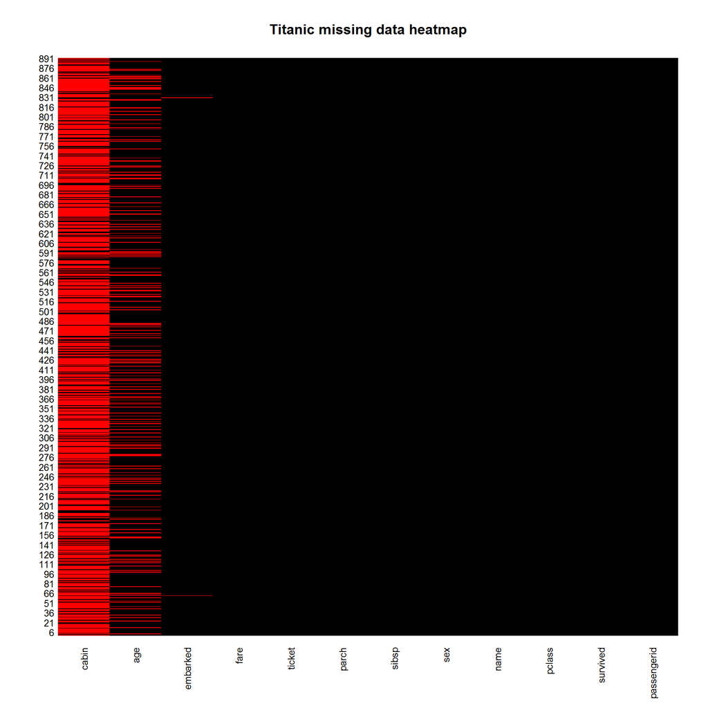

```
## passengerid    survived      pclass        name         sex         age
##           0           0           0           0           0         177
##       sibsp       parch      ticket        fare       cabin    embarked
##           0           0           0           0         687           2
```

### Visualize them all!!!

I create the custom function for reusability. Some variables (passengerid, ticket, and cabin) are omitted from the analysis.

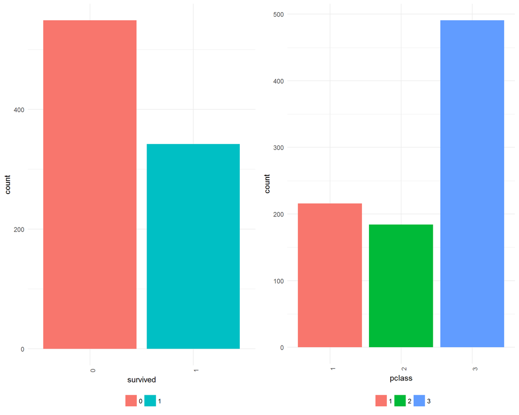

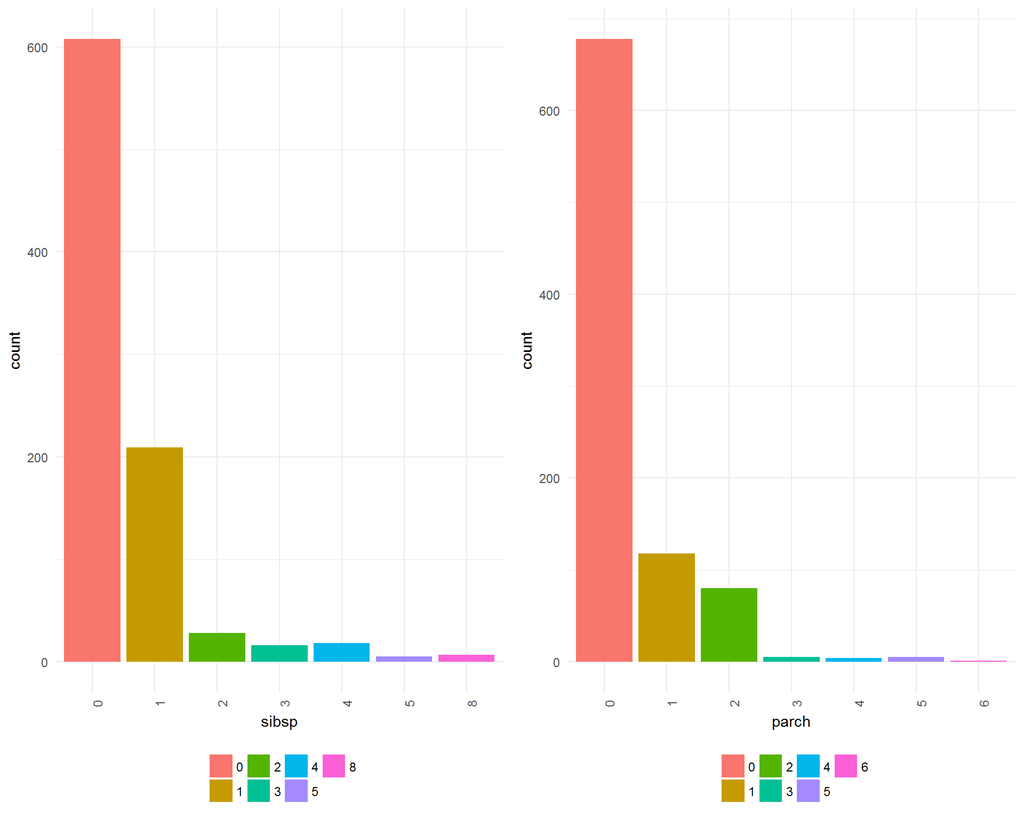

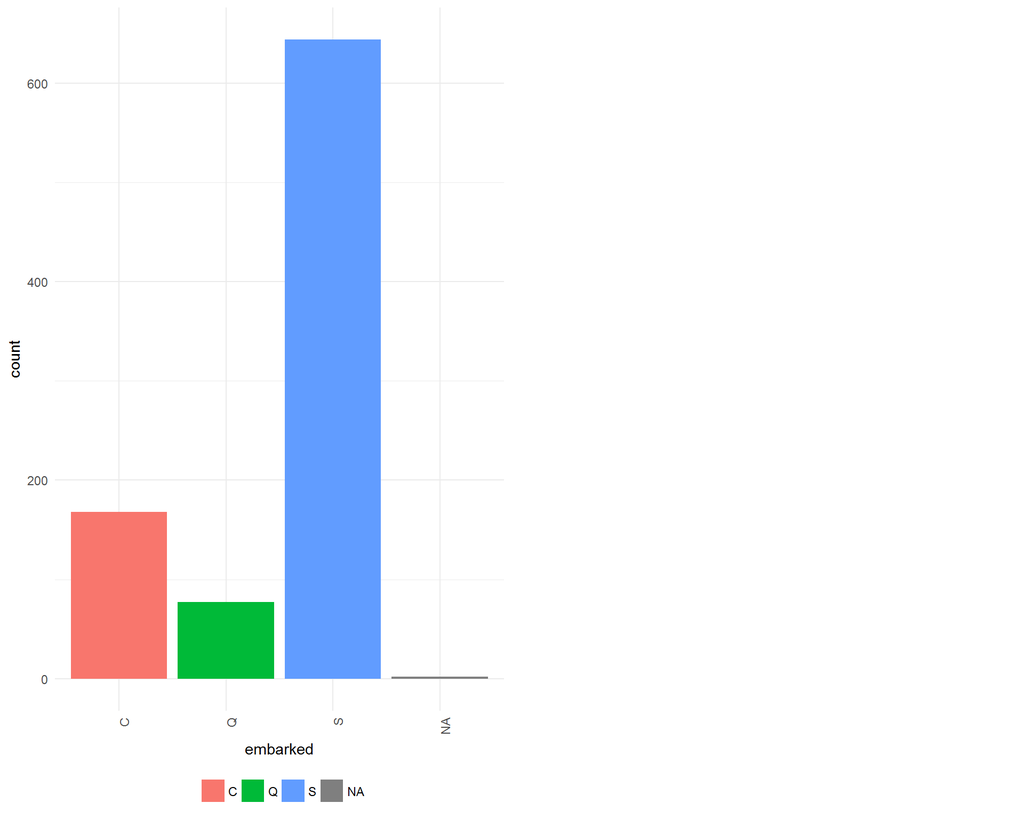

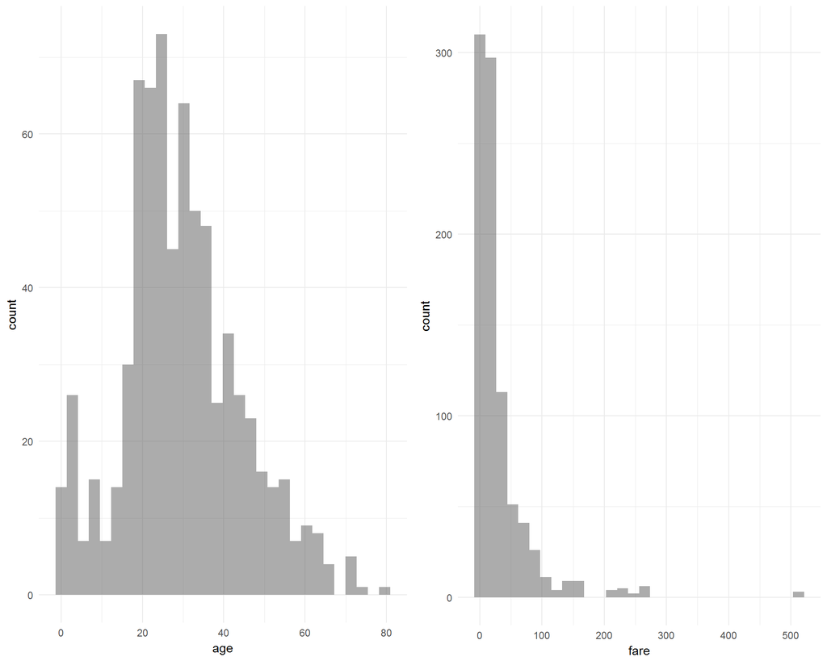

Is there any known hypothesis from the data? I use the *vcd* library, this is very quick and easy way to visualize. In other situation, this kind of plot is very useful for anyone to understand.

This outlook show that gender and travelling class are highly related.

1. Female gender tends to survive more, hence, gender may impact the order to get onto the lifeboat
2. Higher the travelling class, the more likelihood to survive as they may get easier access to lifeboat.
3. Passenger from Cherbourg seems to survive more than other ports, but in deeper look, there are more 1st class passengers from there. Hence, this is somewhat linked to point 2

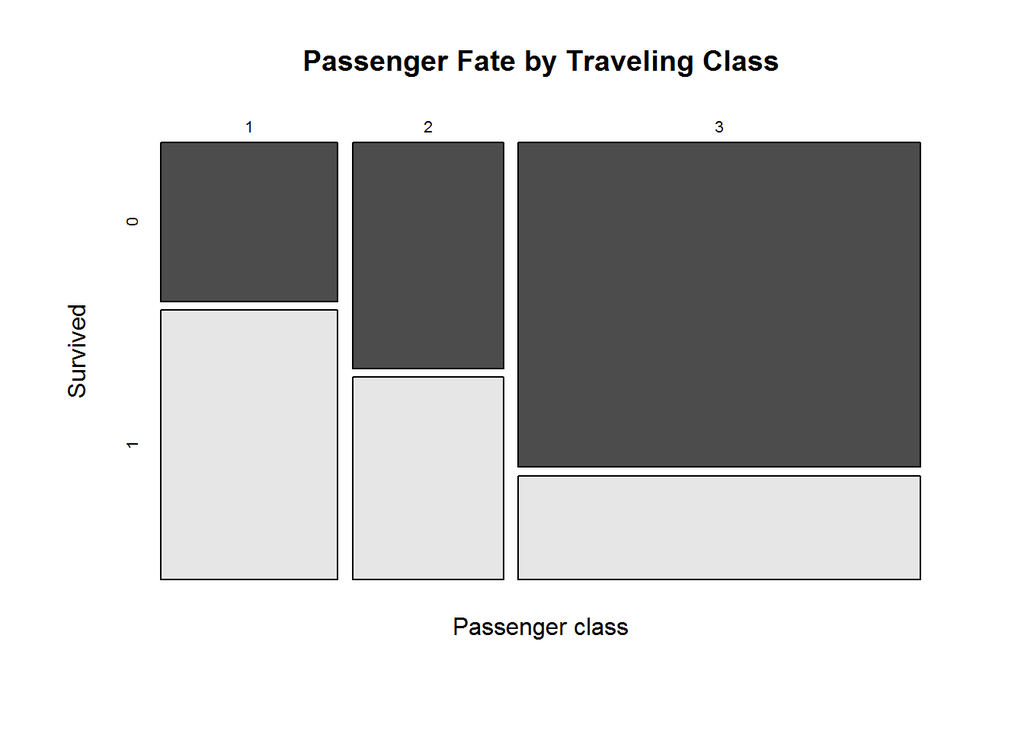

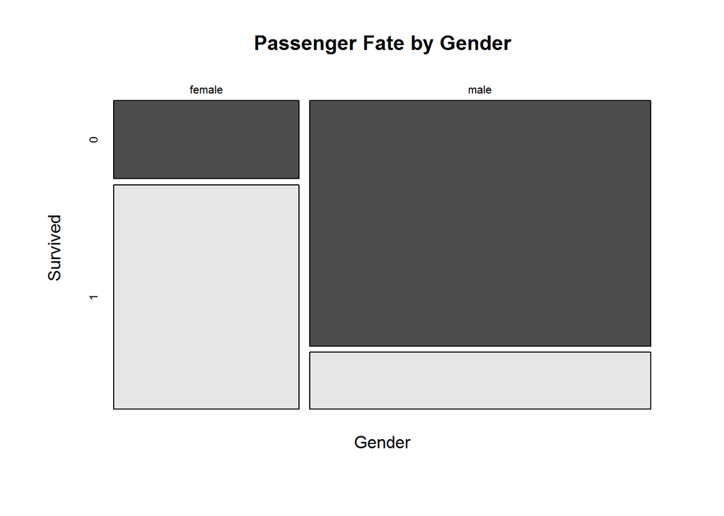

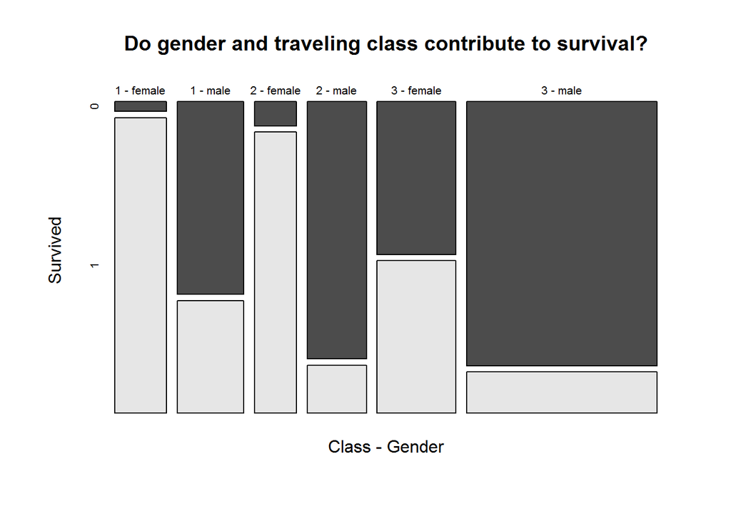

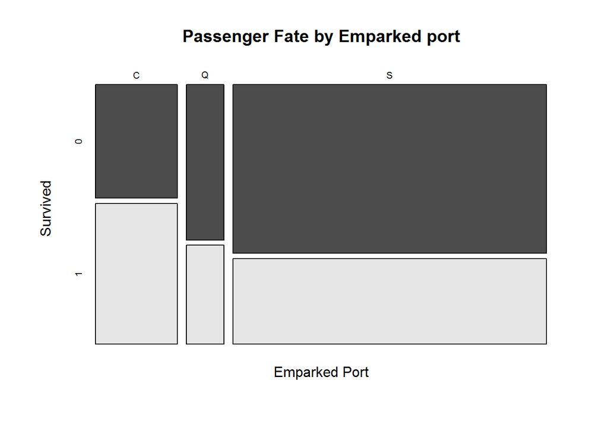

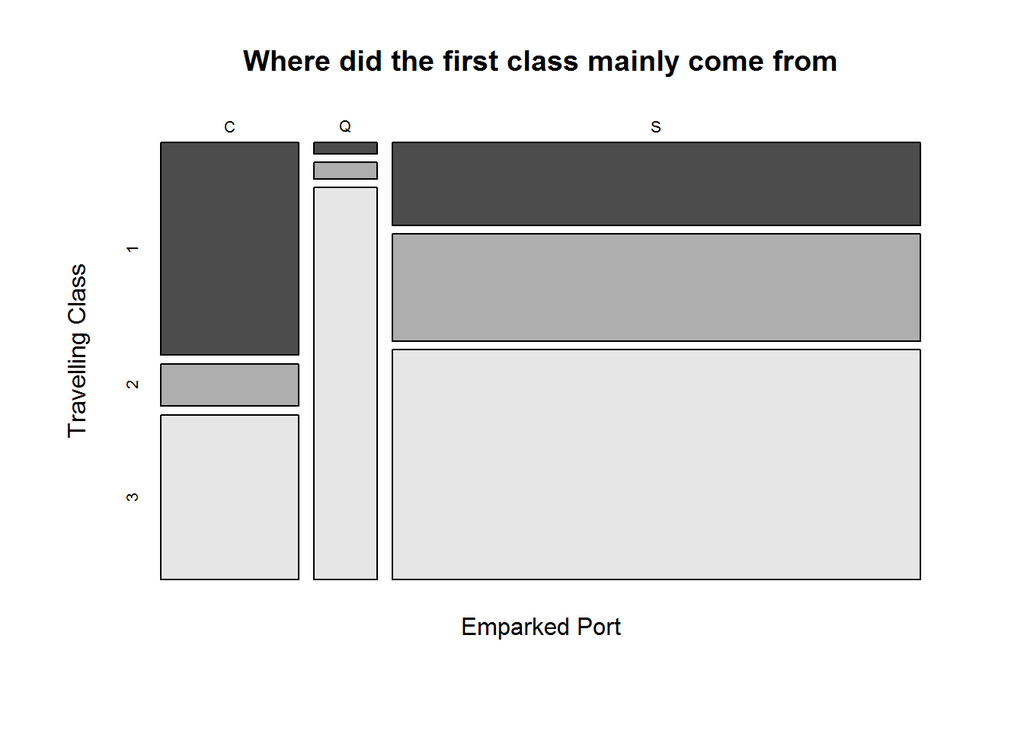

```r
library(vcd)
mosaicplot(training.data$pclass ~ training.data$survived,
           main="Passenger Fate by Traveling Class", shade=FALSE,
           color=TRUE, xlab="Passenger class", ylab="Survived")
```

Another hypothesis is on the age, will the age impact the chance to survive? I found this hypothesis hard to visualize at first glance and there’re a lot of missing data, we haven’t deal with.

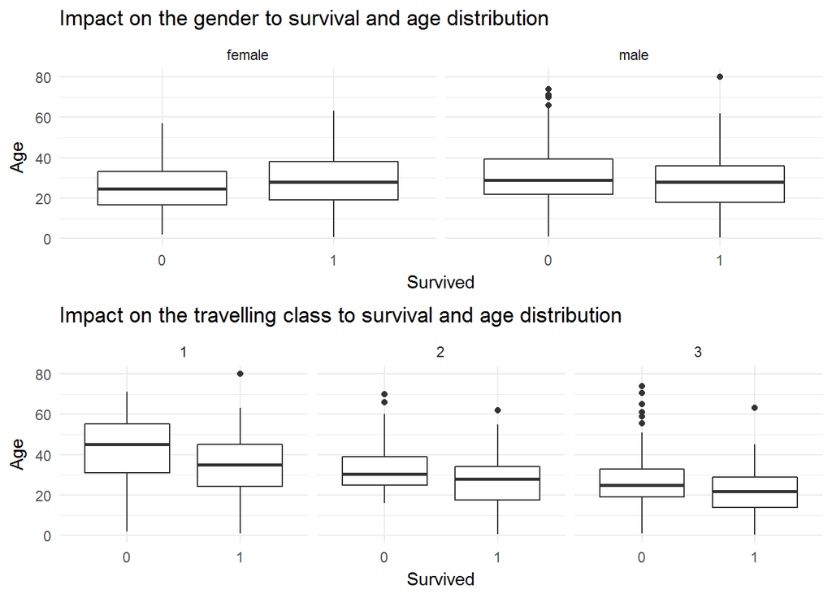

### Fixing the Missing

We are provided with name in the dataset, the name pattern in the dataset is also consistency (with the combination of *Surname, Title First name*). We will try to create new feature, namely **title**, to assist in assigning the age and see if this helps in prediction.

```
## The initial title after parsing
```

```
##
##         Capt          Col          Don           Dr     Jonkheer
##            1            2            1            7            1
##         Lady        Major       Master         Miss         Mlle
##            1            2           40          182            2
##          Mme           Mr          Mrs           Ms          Rev
##            1          517          125            1            6
##          Sir the Countess
##            1            1
```

There are quite a lot, however some titles are actually the same but due to the passager class. I want to simplify this as we already have reliable features *pclass* as class identifier.

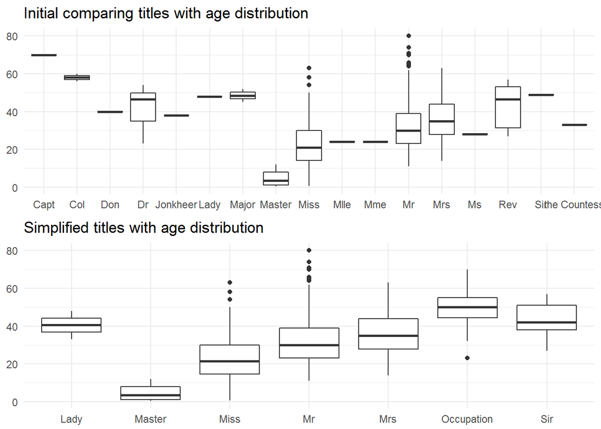

This looks good to me. Now let’s see which titles have the missing age and their mean and median ages. This can be done with **Hmisc** library. We are also stored the titles with missing data into a temporary vector.

```r
library(Hmisc)
bystats(training.data$age, training.data$titles,
        fun=function(x)c(Mean=mean(x), Median(median(x))))

missing.age <- unique(training.data$titles[sapply(training.data$age, is.na)])
```

```
##
##  c(4, 13, 4, 56, 13, 56, 4, 4) of training.data$age by training.data$titles
##
##              N Missing Mean Median
## Lady         2       0 40.5   40.5
## Master      36       4  4.6    3.5
## Miss       150      36 21.9   21.5
## Mr         398     119 32.4   30.0
## Mrs        108      17 35.9   35.0
## Occupation  11       1 48.6   50.0
## Sir          9       0 42.9   42.0
## ALL        714     177 29.7   28.0
```

```
## [1] Mr         Mrs        Miss       Master     Occupation
## Levels: Lady Master Miss Mr Mrs Occupation Sir
```

This basic custom function can use to help fixing each of the missing ages. This variable looks ok to me now.

```r
fill.NA.with.Median <- function(df.var, filter.var, var.list) {
  for (v in var.list) {
    df.var[which(filter.var == v & is.na(df.var))] <- median(df.var[which(filter.var == v)], na.rm=T)
  }
  return (df.var)
}
```

```
##
##  c(9, 13, 9, 56, 13, 56, 9, 9) of training.data$age by training.data$titles
##
##              N Mean Median
## Lady         2 40.5   40.5
## Master      40  4.5    3.5
## Miss       186 21.8   21.5
## Mr         517 31.8   30.0
## Mrs        125 35.8   35.0
## Occupation  12 48.8   50.0
## Sir          9 42.9   42.0
## ALL        891 29.4   30.0
```

Continue to fix the next 2 variables I’m interested in;

- embarked - 2 missings
- fare - this is not missing but some data have fare = 0, we will fix this as well

To fix embarked, looking at the fare comparing to the median of the same class passengers and same cabin (which is 1st class and cabin starts with B). The closest one is ‘C’, hence I will assign this to the missing embarked. *(**Note**: the quick and dirty way, is to use the mode of **embarked** from the entire datasets, this will give us S port instead).*

```r
training.data$embarked[which(is.na(training.data$embarked))] <- 'C'
```

```
##    C    Q    S NA's
##  168   77  644    2
```

```
##   embarked pclass fare cabin
## 1     <NA>      1   80   B28
## 2     <NA>      1   80   B28
```

```
##
##  c(13, 37, 13, 80, 37, 80, 13, 13) of tmp$fare by tmp$embarked
##
##      N Mean Median
## C   22  146     79
## S   23   85     86
## ALL 45  115     79
```

I will apply the similar concept to fix fare by examining the embarked port and passenger class and compare with median of the same grouping.

There are 15 observations - all embarked from Southampton port. Below display the mean and median of fare for each passenger class deporting from Southampton, I will use the median to pad the missing fare for each class.

```
##    fare embarked pclass
## 1    NA        S      3
## 2    NA        S      1
## 3    NA        S      3
## 4    NA        S      2
## 5    NA        S      3
## 6    NA        S      2
## 7    NA        S      2
## 8    NA        S      2
## 9    NA        S      3
## 10   NA        S      1
## 11   NA        S      2
## 12   NA        S      2
## 13   NA        S      1
## 14   NA        S      1
## 15   NA        S      1
```

```
##
##  c(11, 35, 11, 78, 35, 78, 11, 11) of tmp$fare by tmp$pclass
##
##       N Mean Median
## 1   122   73   52.6
## 2   158   21   14.5
## 3   349   15    8.1
## ALL 629   28   13.0
```

```
##
##  c(2, 13, 2, 56, 13, 56, 2, 2) of training.data$fare by training.data$pclass
##
##       N Mean Median
## 1   216   85   60.3
## 2   184   21   14.5
## 3   491   14    8.1
## ALL 891   33   14.5
```

### Prediction

In this model, I will use random forest to demonstrate how we can build the model using the **randomForest** library as well as using **party** library.

I have used following features for prediction and use **caret:createDataPartition** to divide the given training dataset onto training (80%) and testing datasets (20%).

```r
col.to.use <- c("survived", "pclass", "sex", "age", "sibsp", "parch", "fare", "embarked", "titles")

library(caret)
set.seed(23)
intraining <- createDataPartition(training.data.prep$survived,
                                  p = 0.8, list = FALSE)
```

Below show the plot from different random forest library.

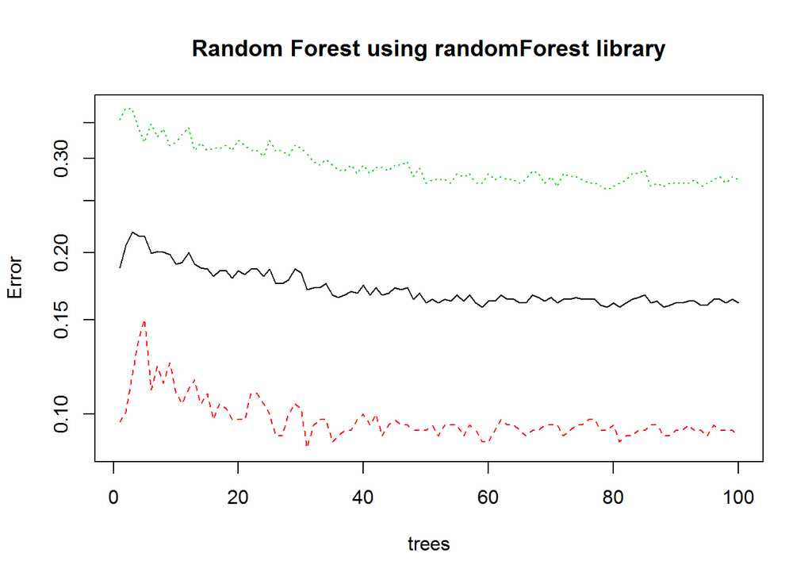

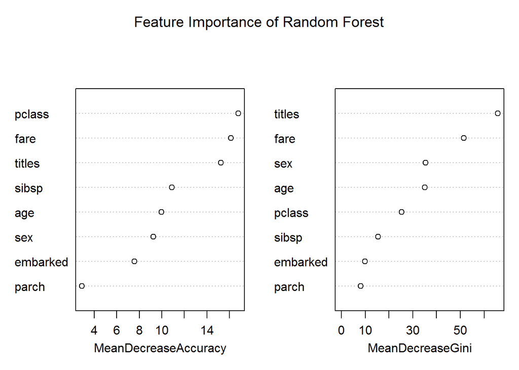

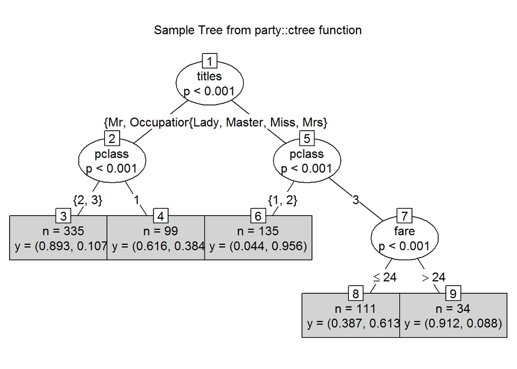

Outcome from randomForest library

```r
confusionMatrix(test.batch.rf.pred, test.batch$survived)
```

```
## Confusion Matrix and Statistics
##
##           Reference
## Prediction  0  1
##          0 96 18
##          1 13 50
##
##                Accuracy : 0.825
##                  95% CI : (0.761, 0.878)
##     No Information Rate : 0.616
##     P-Value [Acc > NIR] : 1.3e-09
##
##                   Kappa : 0.625
##  Mcnemar's Test P-Value : 0.472
##
##             Sensitivity : 0.881
##             Specificity : 0.735
##          Pos Pred Value : 0.842
##          Neg Pred Value : 0.794
##              Prevalence : 0.616
##          Detection Rate : 0.542
##    Detection Prevalence : 0.644
##       Balanced Accuracy : 0.808
##
##        'Positive' Class : 0
##
```

Outcome from party library (unbiased forest)

```r
confusionMatrix(test.batch.party.pred, test.batch$survived)
```

```
## Confusion Matrix and Statistics
##
##           Reference
## Prediction   0   1
##          0 102  16
##          1   7  52
##
##                Accuracy : 0.87
##                  95% CI : (0.811, 0.916)
##     No Information Rate : 0.616
##     P-Value [Acc > NIR] : 6e-14
##
##                   Kappa : 0.718
##  Mcnemar's Test P-Value : 0.0953
##
##             Sensitivity : 0.936
##             Specificity : 0.765
##          Pos Pred Value : 0.864
##          Neg Pred Value : 0.881
##              Prevalence : 0.616
##          Detection Rate : 0.576
##    Detection Prevalence : 0.667
##       Balanced Accuracy : 0.850
##
##        'Positive' Class : 0
##
```

### Final Thoughts

The outcome is quite good (without any tuning, tree pruning). Both models give satisfied results, with cforest predicted better, I have submitted the Titanic competition with results from cforest, which gives me around 0.79 score in the leaderboard.

Next step which I believe is useful or worth looking, if interested:

1. Family size - Does travel with family give you more chance to survive?
2. Try pruning the tree to improve current model techniques
3. Implement other model techniques (such as SVM, XGboost, regression)